# Finding a Significant Relationship between GDP & C02 Emissions

## Visualizing the data

```r
library(reshape2)
library(ggplot2)
```

Using ggplot we create a stacked bar graph to show percentages

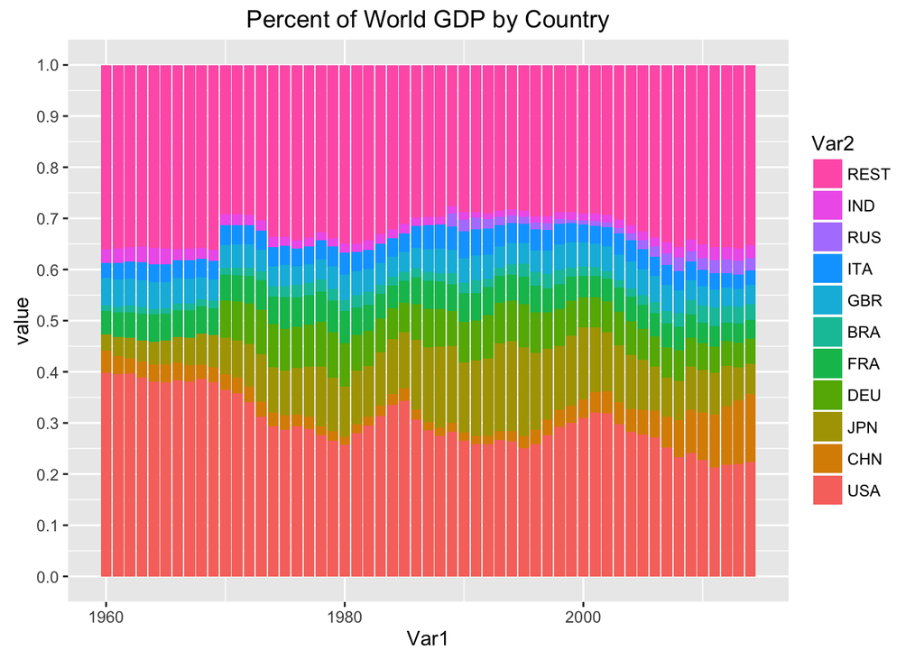

# U.S. GDP vs. CO2 Emissions

We attempted to determine whether there is a statistically significant relationship between CO2 emissions and GDP by regressing CO2 emissions, consumer pricing index (CPI), labor productivity, and employment on GDP. The variation caused by CPI, labor productivity, and employment is controlled for by including them in the model and setting them equal to zero in the resulting function. This would allow us to focus on the variation in GDP caused by CO2 emissions.

```
##
## Call:
## lm(formula = dGDP ~ dCO2 + dCPI + dLP + dEmpl)
##
## Residuals:
##     Min      1Q  Median      3Q     Max
## -389.83  -95.87  -28.98  104.18  303.16
##
## Coefficients:
##               Estimate Std. Error t value Pr(>|t|)
## (Intercept)  6.094e+01  1.022e+02   0.596 0.554792
## dCO2        -1.920e-01  2.969e-01  -0.647 0.522019
## dCPI         2.018e+01  1.590e+01   1.269 0.212502
## dLP          1.653e+04  4.004e+03   4.128 0.000207 ***
## dEmpl        4.422e-02  2.182e-02   2.026 0.050216 .
## ---
## Signif. codes:  0 '***' 0.001 '**' 0.01 '*' 0.05 '.' 0.1 ' ' 1
##
## Residual standard error: 164.3 on 36 degrees of freedom
## Multiple R-squared:  0.4527, Adjusted R-squared:  0.3919
## F-statistic: 7.445 on 4 and 36 DF,  p-value: 0.0001774
```

As shown above, in this model only labor productivity and employment are statistically significant, though employment is only significant at the 90% confidence level. Since we have not been able to find a relationship between CO2 emissions and GDP, we decided to determine whether there was instead a realtionshp between CO2 emissions and any economic sectors.

# Manufacturing Sector vs. CO2 Emissions

We thought that there may be a decline in output in energy intensive sectors (resulting in a decline in CO2 emissions), but a simultaneous rise in output from the information sector which would lend to the continued growth in GDP. Along with the information sector, a number of energy intensive sectors were examined, though we will only review two: manufacturing and information.

With the manufacturing sector, we again attempted to control for several variables in the linear model. This model includes employment in manufacturing, average weekly hours worked in manufacturing, CPI, and CO2 emissions regressed on output from manufacturing.

```
##
## Call:
## lm(formula = dManu ~ dCO2 + dManuEmpl + dManuHours + dCPI)
##
## Residuals:
##    Min     1Q Median     3Q    Max
## -65346 -13776   1088  18650  42649
##
## Coefficients:
##              Estimate Std. Error t value Pr(>|t|)
## (Intercept) 19560.822  12481.412   1.567 0.125818
## dCO2           48.945     39.357   1.244 0.221682
## dManuEmpl      20.776      9.862   2.107 0.042189 *
## dManuHours  43285.999  11231.494   3.854 0.000461 ***
## dCPI         5327.165   2355.061   2.262 0.029832 *
## ---
## Signif. codes:  0 '***' 0.001 '**' 0.01 '*' 0.05 '.' 0.1 ' ' 1
##
## Residual standard error: 26100 on 36 degrees of freedom
## Multiple R-squared:  0.6474, Adjusted R-squared:  0.6082
## F-statistic: 16.53 on 4 and 36 DF,  p-value: 8.971e-08
```

In the model for the manufacturing sector, all of the coefficients are significantly different from zero except for the coefficient of CO2 emissions. We are still not able to show a relationshp between CO2 emissions and output.

# Information Sector vs. CO2 Emissions

The linear model for the information sector includes CO2 emissions, employment in information, labor productivity, and CPI regressed on information output.

```
##
## Call:
## lm(formula = dInfo ~ dCO2 + dInfoEmpl + dLP + dCPI)
##
## Residuals:
##    Min     1Q Median     3Q    Max
## -34680  -9824  -1620   7096  35997
##
## Coefficients:
##              Estimate Std. Error t value Pr(>|t|)
## (Intercept)   3604.57    9689.95   0.372    0.712
## dCO2            33.42      23.46   1.425    0.163
## dInfoEmpl      -33.10      30.57  -1.083    0.286
## dLP         604952.25  381366.47   1.586    0.121
## dCPI          1856.21    1526.63   1.216    0.232
##
## Residual standard error: 16090 on 36 degrees of freedom
## Multiple R-squared:  0.2132, Adjusted R-squared:  0.1257
## F-statistic: 2.438 on 4 and 36 DF,  p-value: 0.06463
```

This model is obviously a very poor representation of the information sector as we were not able to identify any independent variables which caused variation accounted for variation of the information sector. None of our estimators are significantly different from zero. Even the F-statistic is not quite high enough to show any joint significance among the coefficients.

# U.S. GDP vs. CO2 Emissions

### Allowing the Effect of CO2 Emissions to Vary with Time

The final linear model that we created allows the for CO2 emissions to have a different relationship with GDP before and after the “decoupling” of GDP and CO2 emissions which we estimated to begin in 2004 (when CO2 emissions begin to decline). In order to do this, we created a dummy variable which is equal to zero before 2004 and one from 2004 onward. The dummy variable is interacted with CO2 emissions in order to allow the relationship between CO2 emissions and GDP to differ before and after the suspected decoupling.

```
##
## Call:
## lm(formula = dGDP ~ dCO2 + dCPI + dLP + dEmpl + Aft + dAftCO2)
##
## Residuals:
##     Min      1Q  Median      3Q     Max
## -375.46  -65.53   16.68   59.83  315.07
##
## Coefficients:
##               Estimate Std. Error t value Pr(>|t|)
## (Intercept)  1.193e+02  7.854e+01   1.519  0.13793
## dCO2        -4.941e-01  2.744e-01  -1.801  0.08064 .
## dCPI         3.904e-01  1.264e+01   0.031  0.97555
## dLP          1.375e+04  3.056e+03   4.498 7.61e-05 ***
## dEmpl        5.777e-02  1.650e-02   3.502  0.00131 **
## Aft          2.192e+02  4.599e+01   4.767 3.44e-05 ***
## dAftCO2      9.375e-01  2.936e-01   3.194  0.00303 **
## ---
## Signif. codes:  0 '***' 0.001 '**' 0.01 '*' 0.05 '.' 0.1 ' ' 1
##
## Residual standard error: 122.1 on 34 degrees of freedom
## Multiple R-squared:  0.7143, Adjusted R-squared:  0.6639
## F-statistic: 14.17 on 6 and 34 DF,  p-value: 5.124e-08
```

The result of this linear model appears to be unintuitive. Both CO2 coefficients are statistically significant at the 90% confidence level (the interaction coefficient at the 99% confidence level). However, we expected that the relationship betweeen CO2 emissions and GDP would be positive before the decoupling and negative after when CO2 emissions are declining but GDP continues to increase. What we found in this linear model is the opposite. It is possible that either CO2 or GDP needs to be lagged–one may cause a change in the other, but it doesn’t appear until a year (or more) later.